# Structural Question 1: LBD Dihedral Shifts

### φ/ψ Dihedral Analysis of NR1 Ligand-Binding Domain

Author: **Vallari Eastman**  
Date: **October 2025**

### Formal Structural Question 1:

What can phi (φ) and psi (ψ) dihedral angle analysis of the ligand-binding domain (LBD) reveal about conformational changes in NR1 between agonist- and antagonist-bound states?

### Introduction:

The crystal structure of the NR1 ligand-binding domain (LBD) provides a detailed molecular framework for understanding how glycine binding drives NMDA receptor activation. Furukawa & Gouaux (2003) describe the structural organization of the NR1 ligand-binding domain (LBD) as composed of two discontinuous polypeptide segments: S1 (N-terminal portion) forming lobe D1 and S2 (C-terminal portion) forming lobe D2. Together, they fold into a hinged bilobed clamshell typical of ionotri=opic glutamate receptor LBDs. Upon agonist (glycine) binding, the D2 lobe rotates and moves toward D1, resulting in cleft closure that pulls on the transmembrane gating linkers, coupling ligand binding to pore opening (Furukawa & Gouaux, 2003). This cleft closure represents a key conformational change that transmits mechanical force via the S2–M3 linker to open the ion channel gate (Furukawa & Gouaux, 2003). Furukawa & Gouaux (2003) used the crystal structure PDB 1PBQ and noted that key residues forming the binding cleft include: D1 residues (Thr518, Arg523) form the rigid anchoring surface, holding glycine in place, D2 residues (Ser688, Thr690, Glu712, Asp732) form the mobile “closing” lobe, which moves toward D1 when glycine binds, and the resulting D1–D2 cleft closure is the mechanical trigger that initiates channel gating through tension on the S2–M3 linker (Figure 1).

[figure not shown]

**Figure 1.** Structural representation of the NR1 ligand-binding domain (LBD) showing the S1–S2 clamshell configuration (Furukawa & Gouaux, 2003). The GT linker (Gly–Thr linker) connects the LBD (S2 segment) to the transmembrane M3 helix, which forms the channel gate. When the D1–D2 cleft closes upon glycine binding, the D2 lobe moves toward D1, pulling on this GT linker. This tension is transmitted to the M3 helix, triggering channel opening. The disulfide (S–S) bonds stabilize the LBD’s tertiary structure and maintain the correct orientation of the D1 and D2 lobes. There are two key disulfide pairs: C420–C454 and C436–C455 (in D1) and C744–C798 (in D2). These S–S bonds act as structural scaffolds, ensuring the lobes retain rigidity where needed and that the hinge region (D1–D2 interface) can flex predictably without unfolding. Loop 1 (in Domain 1) connects secondary-structure elements (e.g., β-strands J and K) within D1. This helps stabilize the orientation of D1 relative to D2, contributing to the proper positioning of the glycine-binding pocket. Its conformational stability helps define the “rigid” half of the clamshell. Loop 2 (in Domain 2) is more flexible and directly involved in the hinge motion between D1 and D2. It plays a major role in closing the clamshell during agonist binding. Functionally, Loop 2 interacts with other receptor subunits (especially the GluN2 NTD α5 helix; Bleier et al., 2024), serving as an allosteric coupling site that tunes open probability (Po).

The ligand-binding domain (LBD) of the NMDA receptor subunit NR1 (GluN1) undergoes substantial conformational rearrangements during activation, transitioning from an open “apo” state to a closed “agonist-bound” state upon glycine and glutamate binding. Bleier and colleagues (2024) directly compared NR1/NR2A-D receptor conformations in apo-like, partially agonized, and fully agonized states using single-molecule FRET. They found that in the absence of agonists (apo state), the NR1/NR2B receptor adopts a loosely packed, flexible conformation that likely contributes to its lower open probability and slower gating (Bleier et al., 2024). When fully agonized (glycine + glutamate) conformation, all subtypes converge to a similar, compact NR1-LBD arrangement (Bleier et al., 2024). However, the NR1-NTD conformation remains subtype-specific, even when fully agonized, the NR1/NR2B NTD stays relatively open, suggesting that NTD separation correlates with its lower open probability (Bleier et al., 2024).

[figure not shown]

**Figure 2.** NR1 Subunit within the Tetramer:  
The light grey ribbon represents one NR1 subunit, and the black ribbon represents its paired NR2 subunit within the heterodimer (Bleier et al., 2024). As two GluN1–GluN2 heterodimers form a dimer-of-dimers around the central ion pore, the NR1 subunit sits diagonally above NR2, and their ligand-binding domains (LBDs) and N-terminal domains (NTDs) are tightly coupled through multiple interfaces. D1–D2 describe the lobes of the ligand-binding clamshell (where the D1–D2 cleft closes upon agonist binding), while R1–R2 describe the lobes of the N-terminal modulatory domain (which can splay apart or compact depending on receptor subtype and allosteric modulation). The NTDs form the modulatory layer, while the LBDs form the ligand-binding and gating layer immediately above the transmembrane region. These two layers communicate mechanically - when ligands bind at the LBD, conformational strain propagates upward into the NTDs and downward to the channel gate.

[figure not shown]

**Figure 3.** GluN1 subunit confomrationacross different NMDA receptor subtypes (NR1/NR2A–D):  
When GluN2A is in apo and fully agonized states its confomrations look quite similar: the NTDs and LBDs are already compact at rest, consistent with high open probability (Po ~0.5). this indicates a receptor that’s “primed” for activation. For GluN2B, the NTDs are splayed open in the apo state and separate even further upon glutamate binding, while LBDs close normally. This decoupling between NTD and LBD explains its lower Po and distinct allosteric modulation. Both GluN2C / GluN2D exhibit very open, dynamic NTDs and LBDs in the apo state, which only compact upon full agonist binding. Reflects low Po, slow activation, and greater flexibility — consistent with their physiological role in tonic or extrasynaptic signaling.

Bleier and colleagues (2024) directly measured distances between NR1-LBD lobes (site D677) and found that agonist binding (glycine + glutamate) causes the LBDs to move closer together, consistent with D1–D2 cleft closure. Though the local backbone motions in the D1–D2 lobes (cleft closure) remain a universal gating step, the efficiency of mechanical coupling from that local motion to the pore varies with GluN2 subtype (Bleier et al., 2024). In NR1/NR2A receptors, ligand-induced closure of the GluN1 LBD transmits efficiently through the NTD–LBD interface to open the ion channel, resulting in a high open probability (Po ≈ 0.5), whereas in NR1/NR2B receptors, the LBDs still close upon agonist binding but the NTDs remain more splayed, weakening interdomain coupling and producing a lower open probability (Bleier et al., 2024).

A lower open probability (Po) means the NMDA receptor channel spends less time in the open, ion-conducting state, even when both agonists (glycine and glutamate) are bound. For NR1/NR2B, this has several physiological and pharmacological implications including slower channel gating kinetics, prolonged but weaker synaptic currents, and greater susceptibility to modulation by allosteric regulators such as zinc, protons, and ifenprodil (Bleier et al., 2024). Functionally, this allows NR1/NR2B receptors to shape slower, more sustained calcium signaling that supports processes like synaptic plasticity and developmental refinement, while pharmacologically making them a prime target for subtype-selective inhibitors that exploit their unique, low-Po conformational landscape.

This hinge region represents a structural “control point” where small molecules, antibodies, or allosteric modulators could stabilize specific conformations (open, closed, or intermediate). By identifying residues whose backbone geometry changes most dramatically between states, we can pinpoint flexible or energetically sensitive sites that define the LBD’s conformational energy landscape. These hinge and loop residues, therefore, may serve as allosteric drug-binding hotspots, allowing selective modulation of NR1 activity.

Building on these structural and conformational findings, I hypothesize that hinge and loop residues at the D1–D2 interface of the NR1 ligand-binding domain exhibit distinct φ/ψ angle clusters between apo and agonist-bound states. These backbone torsion differences are expected to reflect the clamshell-like opening and closing motion that underlies ligand-induced LBD rearrangement and mechanical coupling to the channel gate. Mapping φ/ψ transitions at the D1–D2 interface helps reveal where and how NR1 can be conformationally “tuned,” a key step in evaluating its structural and functional druggability.

### Hypothesis:

Hinge and loop residues at the D1–D2 interface exhibit distinct φ/ψ angle clusters between apo and agonist-bound states are consistent with clamshell opening/closing.

### Null Hypothesis:

φ/ψ differences are uniform/random across the LBD (no interface clustering), with no association to D1–D2 closure metrics.

### Methods:

φ (phi) and ψ (psi) backbone dihedral angles were computed directly from the atomic coordinates using Biopython’s `PPBuilder().build_peptides()` and `get_phi_psi_list()` functions. Each dihedral was defined geometrically by four consecutive backbone atoms—C(i–1)–N(i)–Cα(i)–C(i) for φ and N(i)–Cα(i)–C(i)–N(i+1) for ψ—and returned in degrees within the range (–180°, +180°]. Residues lacking complete backbone atoms were excluded. For each structure, a sequence of angle-defined residues was generated, filtered for valid φ/ψ pairs, and converted into a one-letter sequence representation.

To ensure residue-level correspondence, the angle-available sequences from 7EU8 and 4KCC were globally aligned using Biopython’s `PairwiseAligner` with the BLOSUM62 substitution matrix (gap open = –10, extend = –0.5). The resulting alignment was used to pair residues one-to-one, reconstructing gapped sequences robustly across Biopython versions. For each aligned residue pair, Δφ and Δψ were computed as circular differences wrapped into (–180°, +180°], and an average deviation metric (|Δ| mean = (|Δφ| + |Δψ|)/2) was calculated to quantify backbone rearrangement.

## Work & Code:

1. Load 7EU8 human NMDA Receptor (NR1/NR2B subtype) and 4KCC rat NR1 LBD and save each of the LBDs

```python
import pymol
pymol.finish_launching(['pymol', '-qc'])
from pymol import cmd

cmd.reinitialize()

# Fetch both structures
cmd.fetch('7EU8')  # human GluN1/2B full receptor
cmd.fetch('4KCC')  # rat NR1 LBD (apo)

# Select the LBD region for chain A of 7EU8 (approximate S1 + S2)
cmd.select('NR1_LBD_A_7EU8', '7EU8 and chain A and polymer.protein and (resi 400-545 or resi 660-800)')
cmd.save('hNR1_LBD_A_7EU8.pdb', 'NR1_LBD_A_7EU8')
print("Saved hNR1_LBD_A_7EU8.pdb")

# Save 4KCC chain A (the deposited LBD)
cmd.select('NR1_LBD_A_4KCC', '4KCC and chain A and polymer.protein')
cmd.save('rNR1_LBD_A_4KCC.pdb', 'NR1_LBD_A_4KCC')
print("Saved rNR1_LBD_A_4KCC.pdb")

cmd.quit()
```

```
Saved hNR1_LBD_A_7EU8.pdb
Saved rNR1_LBD_A_4KCC.pdb
```

2. Align sequences and compare the actual sequences in PDBs to ensure similarity: 7EU8 chain A (human NR1 within the full receptor) vs 4KCC chain A (rat NR1 LBD, apo).

```python
from Bio import Align
from Bio.Align import substitution_matrices
from Bio.PDB import PDBParser, PPBuilder
from IPython.display import display, HTML

def get_sequence(pdb_path, chain_id):
    """Return one-letter AA sequence for given chain."""
    parser = PDBParser(QUIET=True)
    struct = parser.get_structure('x', pdb_path)[0]
    chain = struct[chain_id]
    ppb = PPBuilder()
    seqs = [str(pp.get_sequence()) for pp in ppb.build_peptides(chain, aa_only=True)]
    return "".join(seqs)

seq_7eu8 = get_sequence('hNR1_LBD_A_7EU8.pdb', 'A')
seq_4kcc = get_sequence('rNR1_LBD_A_4KCC.pdb', 'A')

print(f"7EU8 (human NR1 LBD): {len(seq_7eu8)} residues")
print(f"4KCC (rat NR1 LBD):   {len(seq_4kcc)} residues")
print("\n")

aligner = Align.PairwiseAligner()
aligner.mode = "global"
aligner.substitution_matrix = Align.substitution_matrices.load("BLOSUM62")
alignment = aligner.align(seq_7eu8, seq_4kcc)[0]
print(alignment)

# --- Get gapped strings robustly across Biopython versions ---
try:
    # Newer Biopython
    seqA, seqB = str(alignment.seqA), str(alignment.seqB)
except AttributeError:
    # Older Biopython: the alignment is sliceable
    seqA, seqB = map(str, alignment[:2])

seq_7eu8, seq_4kcc = map(str, alignment[:2])

# --- Identity stats ---
identical = sum(a == b for a, b in zip(seq_7eu8, seq_4kcc) if a != '-' and b != '-')
aligned_positions = sum(a != '-' and b != '-' for a, b in zip(seq_7eu8, seq_4kcc))
gapsA = seq_7eu8.count('-')
gapsB = seq_4kcc.count('-')
identity_pct = 100.0 * identical / aligned_positions if aligned_positions else 0.0

print("\nAlignment statistics:")
print(f"  Aligned length        : {len(seqA)}")
print(f"  Positions aligned     : {aligned_positions}")
print(f"  Identical residues    : {identical}")
print(f"  Sequence identity     : {identity_pct:.2f}%")
print(f"  Gaps in 7EU8 sequence : {gapsA}")
print(f"  Gaps in 4KCC sequence : {gapsB}")
```

```
7EU8 (human NR1 LBD): 280 residues
4KCC (rat NR1 LBD):   275 residues


target            0 -----IVTIHQEPFVYVKPTLSDGTCKEEFTVNGDPVKKVICTGPNDTSPGSPRHTVPQC
                  0 -----|||||||||||||||.|||||||||||||||||||||||||--------||||||
query             0 STRLKIVTIHQEPFVYVKPTMSDGTCKEEFTVNGDPVKKVICTGPN--------HTVPQC

target           55 CYGFCIDLLIKLARTMNFTYEVHLVADGKFGTQER-KEWNGMMGELLSGQADMIVAPLTI
                 60 |||||||||||||||||||||||||||||||||||-||||||||||||||||||||||||
query            52 CYGFCIDLLIKLARTMNFTYEVHLVADGKFGTQERVKEWNGMMGELLSGQADMIVAPLTI

target          114 NNERAQYIEFSKPFKYQGLTILVKKEPEE--RITGINDPRLRNPSDKFIYATVKQSSVDI
                120 |||||||||||||||||||||||||------|||||||||||||||||||||||||||||
query           112 NNERAQYIEFSKPFKYQGLTILVKK----GTRITGINDPRLRNPSDKFIYATVKQSSVDI

target          172 YFRRQVELSTMYRHMEKHNYESAAEAIQAVRDNKLHAFIWDSAVLEFEASQKCDLVTTGE
                180 ||||||||||||||||||||||||||||||||||||||||||||||||||||||||||||
query           168 YFRRQVELSTMYRHMEKHNYESAAEAIQAVRDNKLHAFIWDSAVLEFEASQKCDLVTTGE

target          232 LFFRSGFGIGMRKDSPWKQNVSLSILKSHENGFMEDLDKTWVRYQECD 280
                240 |||||||||||||||||||||||||||||||||||||||||||||||- 288
query           228 LFFRSGFGIGMRKDSPWKQNVSLSILKSHENGFMEDLDKTWVRYQEC- 275


Alignment statistics:
  Aligned length        : 288
  Positions aligned     : 267
  Identical residues    : 266
  Sequence identity     : 99.63%
  Gaps in 7EU8 sequence : 8
  Gaps in 4KCC sequence : 13
```

3. **Clean the data:** keeps only residues where both structures have valid ϕ/ψ (removes rows that would be NaN on either side), aligns angle-available sequences so rows correspond 1:1 (no drift), and produces one row per aligned residue pair with columns for bound vs apo and Δ’s.  
4. **Compute φ/ψ** per residue with Biopython and format data

## How φ and ψ Dihedral Angles Were Computed

For each residue in the NR1 ligand-binding domain (LBD), the φ (phi) and ψ (psi) backbone dihedral angles were computed directly from the atomic coordinates in the PDB structures using Biopython’s `PPBuilder().build_peptides()` and `get_phi_psi_list()` functions.

Each angle is defined geometrically from four sequential backbone atoms:

| Angle | Rotation Bond | Atoms Used |
| --- | --- | --- |
| **φ (phi)** | N–Cα | C(i–1) – N(i) – Cα(i) – C(i) |
| **ψ (psi)** | Cα–C | N(i) – Cα(i) – C(i) – N(i+1) |

### Code

from Bio.PDB import PPBuilder  
import math  
ppb = PPBuilder()  
for poly in ppb.build_peptides(chain, aa_only=True):  
for (phi, psi), residue in zip(poly.get_phi_psi_list(), poly):  
phi_deg = math.degrees(phi) if phi is not None else None  
psi_deg = math.degrees(psi) if psi is not None else None  
# store phi_deg, psi_deg for residue.get_id() / sequence index

### Why This Matters

The φ/ψ angles describe local backbone conformation, the geometric “fold” at each residue. By comparing φ/ψ between the apo (**4KCC**) and agonist-bound (**7EU8**) NR1 structures, conformational changes that underlie hinge motion during receptor activation can be quantified.

The dihedral angle is calculated as the torsion between two planes:

θ = atan2((b₂u · (n₁ × n₂)), (n₁ · n₂))

where b₀, b₁, b₂ are the bond vectors connecting the four atoms. The result is reported in degrees, ranging from −180° to +180°.

```python
import math
import numpy as np
import pandas as pd
import re
# Build df_bound / df_apo from the saved LBD PDBs

PDB_BOUND = "hNR1_LBD_A_7EU8.pdb"   # human NR1 LBD (agonist-bound)
PDB_APO   = "rNR1_LBD_A_4KCC.pdb"   # rat NR1 LBD (apo)
CHAIN_ID  = "A"                      # your selections used chain A

# minimal 3-letter -> 1-letter map (fallback 'X')
three_to_one = {
    'ALA':'A','ARG':'R','ASN':'N','ASP':'D','CYS':'C','GLN':'Q','GLU':'E','GLY':'G',
    'HIS':'H','ILE':'I','LEU':'L','LYS':'K','MET':'M','PHE':'F','PRO':'P','SER':'S',
    'THR':'T','TRP':'W','TYR':'Y','VAL':'V'
}

def res_id_string(res):
    """Return 'A:508' or 'A:508A' including insertion code."""
    chain = res.get_parent().id
    hetflag, resseq, icode = res.id  # e.g., (' ', 508, 'A')
    icode = (icode or '').strip()
    return f"{chain}:{resseq}{icode}"

def one_letter(res):
    return three_to_one.get(res.get_resname().upper(), 'X')

def compute_phi_psi_table(pdb_path, chain_id="A"):
    """
    Returns a DataFrame with columns:
      aa, res_id, phi_deg, psi_deg
    Includes rows where phi/psi may be None (NaN) if undefined; we’ll filter later.
    """
    parser = PDBParser(QUIET=True)
    struct = parser.get_structure("x", pdb_path)
    # assume first model
    model = next(struct.get_models())
    chain = model[chain_id]

    rows = []
    ppb = PPBuilder()
    # build_peptides splits on breaks; iterate all fragments
    for poly in ppb.build_peptides(chain, aa_only=True):
        phi_psi_list = poly.get_phi_psi_list()
        for (phi, psi), residue in zip(phi_psi_list, poly):
            rows.append({
                "aa": one_letter(residue),
                "res_id": res_id_string(residue),
                "phi_deg": math.degrees(phi) if phi is not None else np.nan,
                "psi_deg": math.degrees(psi) if psi is not None else np.nan,
            })
    return pd.DataFrame(rows)

df_bound = compute_phi_psi_table(PDB_BOUND, CHAIN_ID)  # 7EU8 LBD A
df_apo   = compute_phi_psi_table(PDB_APO,   CHAIN_ID)  # 4KCC LBD A

print(df_bound.head(3))
print(df_apo.head(3))
print(f"Built tables: bound n={len(df_bound)} | apo n={len(df_apo)}")
```

```
  aa res_id     phi_deg     psi_deg
0  I  A:400         NaN  130.600624
1  V  A:401 -103.579108  127.251288
2  T  A:402 -135.213962  137.020895
  aa res_id     phi_deg     psi_deg
0  S    A:3         NaN  -69.891493
1  T    A:4 -124.614262  147.359601
2  R    A:5  -71.950299  136.714029
Built tables: bound n=280 | apo n=275
```

```python
# ---------- Helpers ----------

def angle_seq(df):
    """Return (df_filtered, seq_string) for residues with non-null φ/ψ."""
    df2 = df[pd.notna(df["phi_deg"]) & pd.notna(df["psi_deg"])].reset_index(drop=True)
    seq = "".join(df2["aa"].tolist())
    return df2, seq

def circular_diff_deg(a, b):
    """Smallest signed diff (deg) in (-180, 180]; safe on NaN."""
    if pd.isna(a) or pd.isna(b):
        return np.nan
    d = (a - b + 180.0) % 360.0 - 180.0
    return 180.0 if d == -180.0 else d

def build_gapped_robust(aln, s1, s2):
    """
    Return (gapped_s1, gapped_s2) robustly across Biopython versions.
    Prefers aln.path; falls back to aln.aligned; lastly tries seqA/seqB or slicing.
    """
    # Preferred: stepwise path
    if hasattr(aln, "path") and aln.path is not None:
        g1, g2 = [], []
        path = aln.path
        for (i1, j1), (i2, j2) in zip(path[:-1], path[1:]):
            di, dj = i2 - i1, j2 - j1
            if di == 1 and dj == 1:
                g1.append(s1[i1]); g2.append(s2[j1])
            elif di == 1 and dj == 0:
                g1.append(s1[i1]); g2.append('-')
            elif di == 0 and dj == 1:
                g1.append('-');    g2.append(s2[j1])
            else:
                step = min(di, dj)
                for k in range(step):
                    g1.append(s1[i1+k]); g2.append(s2[j1+k])
                for k in range(di - step):
                    g1.append(s1[i1+step+k]); g2.append('-')
                for k in range(dj - step):
                    g1.append('-'); g2.append(s2[j1+step+k])
        return "".join(g1), "".join(g2)

    # Fallback: block coordinates
    if hasattr(aln, "aligned") and aln.aligned is not None:
        blocks1, blocks2 = aln.aligned  # lists of (start,end) for each sequence
        g1, g2 = [], []
        i = j = 0
        for (s1_start, s1_end), (s2_start, s2_end) in zip(blocks1, blocks2):
            if s1_start > i:
                for k in range(i, s1_start):
                    g1.append(s1[k]); g2.append('-')
                i = s1_start
            if s2_start > j:
                for k in range(j, s2_start):
                    g1.append('-'); g2.append(s2[k])
                j = s2_start
            n = s1_end - s1_start
            for k in range(n):
                g1.append(s1[s1_start+k]); g2.append(s2[s2_start+k])
            i = s1_end; j = s2_end
        if i < len(s1):
            for k in range(i, len(s1)):
                g1.append(s1[k]); g2.append('-')
        if j < len(s2):
            for k in range(j, len(s2)):
                g1.append('-'); g2.append(s2[k])
        return "".join(g1), "".join(g2)

    # Last-ditch conveniences
    if hasattr(aln, "seqA") and hasattr(aln, "seqB"):
        return str(aln.seqA), str(aln.seqB)
    try:
        a, b = aln[:2]
        return str(a), str(b)
    except Exception:
        pass

    raise AttributeError("Alignment lacks .path/.aligned; cannot rebuild gapped strings safely.")

# ---------- 1) Filter to angle-available residues & build sequences ----------

dfb_ang, seqA_angles = angle_seq(df_bound)  # bound (7EU8)
dfa_ang, seqB_angles = angle_seq(df_apo)    # apo (4KCC)

print(f"Angle-available lengths: bound={len(dfb_ang)} | apo={len(dfa_ang)}")

# ---------- 2) Align the angle-available sequences ----------

aligner = Align.PairwiseAligner()
aligner.mode = "global"
aligner.substitution_matrix = substitution_matrices.load("BLOSUM62")
aligner.open_gap_score  = -10
aligner.extend_gap_score = -0.5

aln2 = aligner.align(seqA_angles, seqB_angles)[0]
gA, gB = build_gapped_robust(aln2, seqA_angles, seqB_angles)

# ---------- 3) Walk the gapped strings and assemble the comparison table ----------

iA = iB = 0
rows = []
for k, (a, b) in enumerate(zip(gA, gB)):
    if a != '-' and b != '-':
        Arow = dfb_ang.iloc[iA]
        Brow = dfa_ang.iloc[iB]

        dphi = circular_diff_deg(Arow["phi_deg"], Brow["phi_deg"])
        dpsi = circular_diff_deg(Arow["psi_deg"], Brow["psi_deg"])

        rows.append({
            "SeqPos": iA,  # index among angle-available residues (bound)
            "Residue (bound)": f'{Arow["res_id"].split(":")[1]} {Arow["aa"]}',
            "φ_bound°": round(Arow["phi_deg"], 2),
            "ψ_bound°": round(Arow["psi_deg"], 2),

            "SeqPos (apo)": iB,  # index among angle-available residues (apo)
            "Residue (apo)": f'{Brow["res_id"].split(":")[1]} {Brow["aa"]}',
            "φ_apo°": round(Brow["phi_deg"], 2),
            "ψ_apo°": round(Brow["psi_deg"], 2),

            "Δφ": round(dphi, 2),
            "Δψ": round(dpsi, 2),
            "|Δ| mean": round((abs(dphi) + abs(dpsi)) / 2.0, 2),
        })
        iA += 1
        iB += 1
    elif a != '-' and b == '-':
        iA += 1
    elif a == '-' and b != '-':
        iB += 1
    else:
        # both gaps (rare)
        pass

cmp_df = pd.DataFrame(rows)
print(f"Comparable residues (both have angles): {len(cmp_df)}")

# ---------- 4) Preview + save ----------

from IPython.display import HTML, display
display(HTML(
    "<div style='height:380px; overflow:auto; border:1px solid #bbb; "
    "border-radius:6px; font-family:ui-monospace, Menlo, monospace; font-size:12.5px;'>"
    + cmp_df.to_html(index=False)
    + "</div>"
))

cmp_df.to_csv("NR1_phi_psi_comparison_ANGLE_ALIGNED.csv", index=False)
print("Wrote NR1_phi_psi_comparison_ANGLE_ALIGNED.csv")
```

```
Angle-available lengths: bound=274 | apo=269
Comparable residues (both have angles): 263
```

| SeqPos | Residue (bound) | φ_bound° | ψ_bound° | SeqPos (apo) | Residue (apo) | φ_apo° | ψ_apo° | Δφ | Δψ | \|Δ\| mean |
| --- | --- | --- | --- | --- | --- | --- | --- | --- | --- | --- |
| 0 | 401 V | -103.58 | 127.25 | 5 | 9 V | -107.58 | 140.28 | 4.00 | -13.03 | 8.52 |
| 1 | 402 T | -135.21 | 137.02 | 6 | 10 T | -142.09 | -178.93 | 6.88 | -44.05 | 25.46 |
| 2 | 403 I | -84.74 | 133.42 | 7 | 11 I | -143.93 | 153.41 | 59.18 | -19.99 | 39.59 |
| 3 | 404 H | -74.63 | 74.98 | 8 | 12 H | -74.73 | 112.43 | 0.11 | -37.45 | 18.78 |
| 4 | 405 Q | -99.04 | 121.68 | 9 | 13 Q | -159.76 | 102.99 | 60.72 | 18.70 | 39.71 |
| 5 | 406 E | -55.80 | -44.93 | 10 | 14 E | -68.14 | 148.22 | 12.34 | 166.85 | 89.59 |
| 6 | 407 P | -60.79 | -27.10 | 11 | 15 P | -95.51 | 15.50 | 34.72 | -42.60 | 38.66 |
| 7 | 408 F | -105.24 | -54.65 | 12 | 16 F | -77.33 | -44.29 | -27.91 | -10.35 | 19.13 |
| 8 | 409 V | -133.18 | 106.55 | 13 | 17 V | -140.92 | 111.50 | 7.73 | -4.95 | 6.34 |
| 9 | 410 Y | -71.00 | 146.24 | 14 | 18 Y | -86.79 | 146.23 | 15.78 | 0.01 | 7.90 |
| 10 | 411 V | -122.98 | 127.26 | 15 | 19 V | -129.90 | 124.47 | 6.92 | 2.79 | 4.85 |
| 11 | 412 K | -157.32 | 143.42 | 16 | 20 K | -138.26 | 153.68 | -19.07 | -10.26 | 14.66 |
| 12 | 413 P | -61.10 | 144.58 | 17 | 21 P | -67.36 | 155.33 | 6.26 | -10.75 | 8.50 |
| 13 | 414 T | -81.43 | -175.14 | 18 | 22 T | -70.09 | 158.27 | -11.34 | 26.60 | 18.97 |
| 14 | 415 L | -81.03 | -179.11 | 19 | 23 M | -69.85 | 176.83 | -11.18 | 4.06 | 7.62 |
| 15 | 416 S | -64.70 | -40.73 | 20 | 24 S | -59.19 | -27.09 | -5.52 | -13.64 | 9.58 |
| 16 | 417 D | -69.39 | -17.18 | 21 | 25 D | -93.96 | 1.77 | 24.56 | -18.95 | 21.75 |
| 17 | 418 G | 98.25 | 2.21 | 22 | 26 G | 93.09 | 0.30 | 5.16 | 1.91 | 3.53 |
| 18 | 419 T | -113.41 | 128.17 | 23 | 27 T | -96.19 | 168.34 | -17.21 | -40.16 | 28.69 |
| 19 | 420 C | -67.93 | 139.79 | 24 | 28 C | -95.93 | 132.03 | 28.01 | 7.76 | 17.88 |
| 20 | 421 K | -67.26 | 137.51 | 25 | 29 K | -48.94 | 128.91 | -18.32 | 8.60 | 13.46 |
| 21 | 422 E | -68.70 | 137.45 | 26 | 30 E | -72.51 | 121.19 | 3.81 | 16.26 | 10.03 |
| 22 | 423 E | -113.13 | 127.14 | 27 | 31 E | -129.63 | 161.95 | 16.50 | -34.81 | 25.66 |
| 23 | 424 F | -97.49 | 128.66 | 28 | 32 F | -136.76 | 153.69 | 39.27 | -25.04 | 32.15 |
| 24 | 425 T | -87.51 | -172.26 | 29 | 33 T | -77.20 | 174.44 | -10.31 | 13.30 | 11.80 |
| 25 | 426 V | -65.14 | -43.22 | 30 | 34 V | -60.42 | -26.97 | -4.72 | -16.26 | 10.49 |
| 26 | 427 N | -107.37 | 34.86 | 31 | 35 N | -98.62 | 9.40 | -8.75 | 25.45 | 17.10 |
| 27 | 428 G | 70.58 | -143.38 | 32 | 36 G | 100.93 | -6.07 | -30.34 | -137.32 | 83.83 |
| 28 | 429 D | 53.51 | 71.88 | 33 | 37 D | -75.19 | 136.10 | 128.71 | -64.23 | 96.47 |
| 29 | 430 P | -64.47 | 147.58 | 34 | 38 P | -60.47 | 138.71 | -4.00 | 8.87 | 6.43 |

[output cut: 233 more lines]

```
Wrote NR1_phi_psi_comparison_ANGLE_ALIGNED.csv
```

## Immediate Observations from Table

### Overall trend

Most residues have |Δ| < 20°, representing normal background flexibility. This means the majority of the LBD backbone retains similar local geometry between the apo and bound states.

### Localized clusters of high |Δ|

Abrupt jumps to > 80–100° differences (e.g., residues **429 D**, **663 R**, **731 W**, **753 F**, **795 Y**, **797 E**) are classic signatures of loop or hinge motion—regions where the backbone flips into a different part of the Ramachandran map between states.

**Breaking Down the Numbers**  
`| 429 D | +53.5 | +71.9 | −75.2 | +136.1 | +128.7 | −64.2 | ≈ 96.5° |`  
In the **bound (7EU8)** state, φ = +53° and ψ = +72°, placing it in the upper-right quadrant of the Ramachandran map (the left-handed or extended positive region is rarely occupied by standard β or α residues).  
In the **apo (4KCC)** state, φ = −75° and ψ = +136°, which sits in the canonical β-strand region (top-left quadrant).  
Between apo → bound, the backbone around this Asp flips from β-strand-like (φ ≈ −75°) to an unusual positive-φ conformation (φ ≈ +50°), which is a dramatic change in geometry.

That’s a ~130° swing in φ and ~60° in ψ, which is a |Δ| ≈ 96° a hinge-bend or loop pivot. Residue 429 D sits at the S1–S2 interface (near the linker connecting the D1 and D2 lobes of the LBD), where the following occur during clamshell closure:

- The D1 and D2 lobes rotate toward each other.
- The peptide backbone at the linker “flips” to accommodate the new domain orientation.
- Local torsion angles change drastically (often near Gly, Asp, or Ser).

### Magnitude and sign of Δψ vs Δφ

The Δψ values often dominate, showing larger swings than Δφ. ψ-angle variation typically tracks β-strand twisting and inter-domain closure, while φ remains more restricted by steric limits. This suggests that the main motion is domain rotation rather than local backbone refolding.

```python
# 1) No NaNs in angle/Δ columns
assert cmp_df[["φ_bound°","ψ_bound°","φ_apo°","ψ_apo°","Δφ","Δψ","|Δ| mean"]].isna().sum().sum() == 0

# 2) Δ wrapping sanity (max absolute ≤ 180)
assert (cmp_df["Δφ"].abs().le(180.0001)).all() and (cmp_df["Δψ"].abs().le(180.0001)).all()

# 3) AA match rate (how many substitutions?)
aa_bound = cmp_df["Residue (bound)"].str.split().str[-1]  # last token is 1-letter aa
aa_apo   = cmp_df["Residue (apo)"].str.split().str[-1]
mismatch_rate = (aa_bound != aa_apo).mean()
print(f"AA mismatch rate: {100*mismatch_rate:.2f}% (expected: small but non-zero)")

# 4) Spot outliers
print(cmp_df.sort_values("|Δ| mean", ascending=False).head(10)[
    ["Residue (bound)","Residue (apo)","Δφ","Δψ","|Δ| mean"]
])
```

```
AA mismatch rate: 1.14% (expected: small but non-zero)
    Residue (bound) Residue (apo)      Δφ      Δψ  |Δ| mean
196           731 W         223 W -139.17 -144.67    141.92
260           795 Y         287 Y   75.61  154.03    114.82
218           753 F         245 F   53.06 -172.76    112.91
262           797 E         289 E  -70.17 -149.71    109.94
128           663 R         155 R   49.29 -156.81    103.05
219           754 F         246 F  164.40   39.26    101.83
259           794 R         286 R   26.26 -169.32     97.79
28            429 D          37 D  128.71  -64.23     96.47
111           530 S         138 S  125.06   66.97     96.02
208           743 K         235 K   51.13 -133.75     92.44
```

5. Generate Statistics

```python
import re
import numpy as np
import pandas as pd
from IPython.display import display, HTML

# ---------- helpers ----------
def _p90(s):
    """Return the 90th percentile of a Series, ignoring NaNs."""
    s = pd.to_numeric(s, errors="coerce").dropna()
    return np.percentile(s, 90) if len(s) else np.nan

def _numeric_resnum_from_label(label: str):
    """
    Extract the integer residue number from labels like '401 V' or '508A G' -> 401 / 508.
    Used for coarse region binning.
    """
    if not isinstance(label, str):
        return np.nan
    m = re.search(r"(\d+)", label)
    return int(m.group(1)) if m else np.nan

# ---------------------------------------------------------
# 1) Global φ/ψ difference summary
# ---------------------------------------------------------
# Use NaN-safe conversions to be robust to any missing values.
abs_dphi  = np.abs(pd.to_numeric(cmp_df["Δφ"], errors="coerce"))
abs_dpsi  = np.abs(pd.to_numeric(cmp_df["Δψ"], errors="coerce"))
abs_delta = pd.to_numeric(cmp_df["|Δ| mean"], errors="coerce")

global_stats = {
    "Residues analyzed": int(len(cmp_df)),
    "Mean |Δφ|":         float(np.nanmean(abs_dphi)),
    "Mean |Δψ|":         float(np.nanmean(abs_dpsi)),
    "Mean |Δ|":          float(np.nanmean(abs_delta)),
    "Median |Δ|":        float(np.nanmedian(abs_delta)),
    "90th percentile |Δ|": float(_p90(abs_delta)),
    "Max |Δ|":           float(np.nanmax(abs_delta)),
}
global_table = (
    pd.DataFrame(global_stats.items(), columns=["Metric", "Value"])
      .assign(Value=lambda d: d["Value"].round(2))
)
display(global_table)

# ---------------------------------------------------------
# 2) Regional φ/ψ difference summary
# ---------------------------------------------------------
# Ensure we have a numeric residue index (from bound labels) to assign regions.
if "resnum_bound_num" not in cmp_df.columns:
    if "Residue (bound)" not in cmp_df.columns:
        raise KeyError("cmp_df must contain 'Residue (bound)'.")
    cmp_df["resnum_bound_num"] = cmp_df["Residue (bound)"].map(_numeric_resnum_from_label)

# Define coarse windows (edit as needed). Earlier keys in PRIORITY have precedence.
REGION_WINDOWS = {
    "hinge_S1_end":   (540, 545),
    "hinge_S2_start": (660, 665),
    # Example finer windows (uncomment & add before S1/S2 in PRIORITY to override):
    # "Loop1": (508, 514),
    # "Loop2": (730, 737),
    "S1": (400, 545),
    "S2": (660, 800),
}
REGION_PRIORITY = [
    "hinge_S1_end",
    "hinge_S2_start",
    # "Loop1", "Loop2",
    "S1",
    "S2",
]

def _assign_region(n):
    """Map numeric residue index to a coarse structural region."""
    if pd.isna(n):
        return "unknown"
    for key in REGION_PRIORITY:
        lo, hi = REGION_WINDOWS[key]
        if lo <= n <= hi:
            return key
    return "other"

cmp_df["region"] = cmp_df["resnum_bound_num"].map(_assign_region)

# Regional aggregates (NaN-safe)
region_stats = (
    cmp_df.groupby("region", dropna=False)
          .agg(
              N=("|Δ| mean", "size"),
              mean_abs_dphi=("Δφ",  lambda s: np.nanmean(np.abs(pd.to_numeric(s, errors="coerce")))),
              mean_abs_dpsi=("Δψ",  lambda s: np.nanmean(np.abs(pd.to_numeric(s, errors="coerce")))),
              mean_abs_delta=("|Δ| mean", lambda s: np.nanmean(pd.to_numeric(s, errors="coerce"))),
              sd_abs_delta=("|Δ| mean", lambda s: np.nanstd(pd.to_numeric(s, errors="coerce"), ddof=1)),
              p90_abs_delta=("|Δ| mean", _p90),
              max_abs_delta=("|Δ| mean", lambda s: np.nanmax(pd.to_numeric(s, errors="coerce"))),
          )
          .round(2)
          .sort_values("mean_abs_delta", ascending=False)
)
display(region_stats)

# ---------------------------------------------------------
# 3) Regional % residues exceeding |Δ| threshold
# ---------------------------------------------------------
threshold = 40
prop_over = (abs_delta > threshold).mean() * 100.0
print(f"Residues with |Δ| > {threshold}°: {prop_over:.1f}% of all residues\n")

region_prop = (
    cmp_df.assign(significant = abs_delta > threshold)
          .groupby("region", dropna=False)["significant"]
          .mean()
          .mul(100)
          .round(1)
          .to_frame(f"% |Δ| > {threshold}°")
          .sort_values(f"% |Δ| > {threshold}°", ascending=False)
)
display(region_prop)

# ---------------------------------------------------------
# 4) Top movers (rows with |Δ| ≥ 90th percentile), scrollable preview
# ---------------------------------------------------------
top_cutoff = float(_p90(abs_delta))
top_residues = (
    cmp_df.loc[abs_delta >= top_cutoff, ["Residue (bound)","Residue (apo)","region","Δφ","Δψ","|Δ| mean"]]
          .sort_values("|Δ| mean", ascending=False)
)

display(HTML(
    "<div style='height:480px; overflow:auto; border:1px solid #bbb; "
    "border-radius:6px; font-family:ui-monospace, Menlo, monospace; font-size:12.5px;'>"
    + top_residues.to_html(index=False)
    + "</div>"
))
```

|  | Metric | Value |
| --- | --- | --- |
| 0 | Residues analyzed | 263.00 |
| 1 | Mean \|Δφ\| | 20.75 |
| 2 | Mean \|Δψ\| | 23.33 |
| 3 | Mean \|Δ\| | 22.04 |
| 4 | Median \|Δ\| | 14.46 |
| 5 | 90th percentile \|Δ\| | 43.96 |
| 6 | Max \|Δ\| | 141.92 |

| region | N | mean_abs_dphi | mean_abs_dpsi | mean_abs_delta | sd_abs_delta | p90_abs_delta | max_abs_delta |
| --- | --- | --- | --- | --- | --- | --- | --- |
| hinge_S2_start | 5 | 50.14 | 61.77 | 55.96 | 36.66 | 95.16 | 103.05 |
| S2 | 132 | 20.18 | 23.40 | 21.79 | 26.36 | 45.91 | 141.92 |
| S1 | 121 | 20.29 | 22.35 | 21.32 | 19.10 | 39.59 | 96.47 |
| hinge_S1_end | 5 | 17.28 | 7.03 | 12.15 | 8.49 | 20.68 | 23.98 |

```
Residues with |Δ| > 40°: 11.0% of all residues
```

| region | % \|Δ\| > 40° |
| --- | --- |
| hinge_S2_start | 60.0 |
| S2 | 11.4 |
| S1 | 9.1 |
| hinge_S1_end | 0.0 |

| Residue (bound) | Residue (apo) | region | Δφ | Δψ | \|Δ\| mean |
| --- | --- | --- | --- | --- | --- |
| 731 W | 223 W | S2 | -139.17 | -144.67 | 141.92 |
| 795 Y | 287 Y | S2 | 75.61 | 154.03 | 114.82 |
| 753 F | 245 F | S2 | 53.06 | -172.76 | 112.91 |
| 797 E | 289 E | S2 | -70.17 | -149.71 | 109.94 |
| 663 R | 155 R | hinge_S2_start | 49.29 | -156.81 | 103.05 |
| 754 F | 246 F | S2 | 164.40 | 39.26 | 101.83 |
| 794 R | 286 R | S2 | 26.26 | -169.32 | 97.79 |
| 429 D | 37 D | S1 | 128.71 | -64.23 | 96.47 |
| 530 S | 138 S | S1 | 125.06 | 66.97 | 96.02 |
| 743 K | 235 K | S2 | 51.13 | -133.75 | 92.44 |
| 406 E | 14 E | S1 | 12.34 | 166.85 | 89.59 |
| 744 C | 236 C | S2 | 110.15 | 62.86 | 86.50 |
| 428 G | 36 G | S1 | -30.34 | -137.32 | 83.83 |
| 732 D | 224 D | S2 | -84.63 | -82.58 | 83.61 |
| 661 E | 153 G | hinge_S2_start | 159.91 | -6.74 | 83.33 |
| 529 F | 137 F | S1 | 23.22 | -137.91 | 80.57 |
| 706 M | 198 M | S2 | -67.20 | 87.24 | 77.22 |
| 537 G | 145 G | S1 | 68.22 | -54.86 | 61.54 |
| 679 F | 171 F | S2 | 69.90 | 46.09 | 57.99 |
| 438 G | 46 G | S1 | 84.33 | -27.46 | 55.90 |
| 796 Q | 288 Q | S2 | 34.76 | 71.56 | 53.16 |
| 513 I | 121 I | S1 | -20.87 | -85.33 | 53.10 |
| 730 I | 222 I | S2 | -39.15 | 60.16 | 49.66 |
| 451 V | 59 V | S1 | 69.57 | -26.59 | 48.08 |
| 756 S | 248 S | S2 | 47.14 | -45.02 | 46.08 |
| 674 N | 166 N | S2 | 44.51 | 44.18 | 44.35 |
| 665 T | 157 T | hinge_S2_start | -17.60 | 71.01 | 44.30 |

6. Generate Histogram, Ramachandran Plot and Heatmap

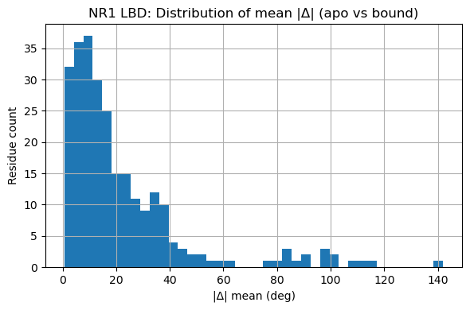

```
Saved fig_nr1_lbd/dist_abs_delta_mean.png
```

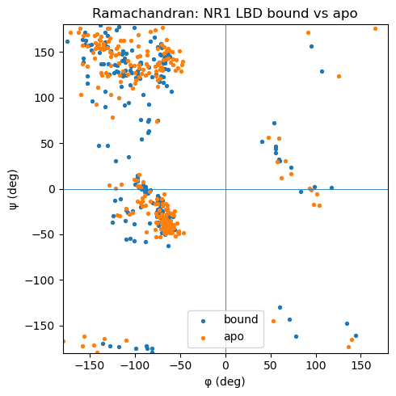

```
Saved fig_nr1_lbd/rama_bound_vs_apo.png
```

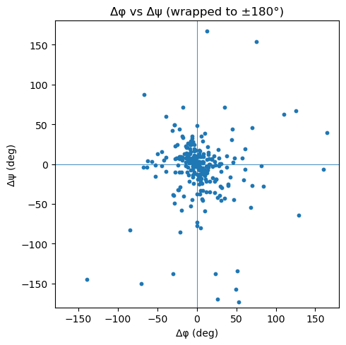

```
Saved fig_nr1_lbd/delta_phi_vs_delta_psi.png
```

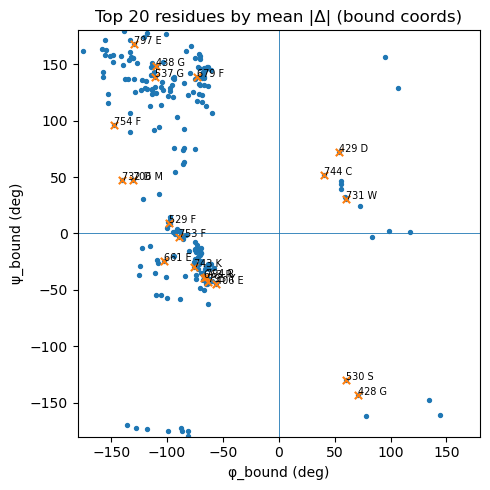

```
Saved fig_nr1_lbd/rama_bound_topN_labels.png
```

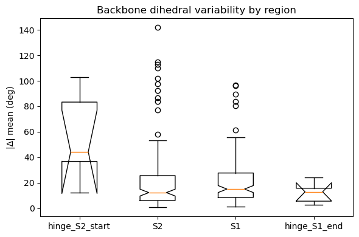

```
Saved fig_nr1_lbd/box_abs_delta_by_region.png
```

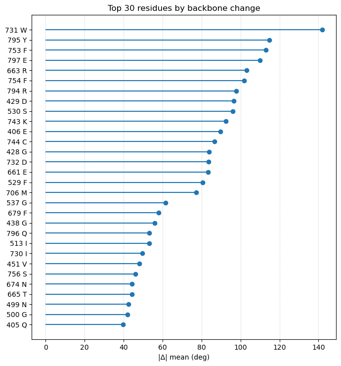

```
Saved fig_nr1_lbd/lollipop_topN_abs_delta.png
```

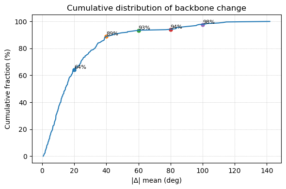

```
Saved fig_nr1_lbd/cdf_abs_delta_mean.png
```

```python
# ===== NR1 dihedral comparison: plotting suite (Matplotlib only) =====
import os
import numpy as np
import pandas as pd
import matplotlib.pyplot as plt

OUTDIR = "fig_nr1_lbd"
os.makedirs(OUTDIR, exist_ok=True)

def _savefig(name):
    path = os.path.join(OUTDIR, name)
    plt.tight_layout()
    plt.savefig(path, dpi=300, bbox_inches="tight")
    plt.show()
    print(f"Saved {path}")

# -----------------------------
# 1) Distribution of |Δ| mean
# -----------------------------
plt.figure(figsize=(6,4))
cmp_df["|Δ| mean"].hist(bins=40)
plt.xlabel("|Δ| mean (deg)")
plt.ylabel("Residue count")
plt.title("NR1 LBD: Distribution of mean |Δ| (apo vs bound)")
_savefig("dist_abs_delta_mean.png")

# -----------------------------------
# 2) Ramachandran: bound vs apo
# -----------------------------------
plt.figure(figsize=(5,5))
plt.scatter(cmp_df["φ_bound°"], cmp_df["ψ_bound°"], s=8, label="bound")
plt.scatter(cmp_df["φ_apo°"],   cmp_df["ψ_apo°"],   s=8, label="apo")
plt.axhline(0, lw=0.6); plt.axvline(0, lw=0.6)
plt.xlim(-180, 180); plt.ylim(-180, 180)
plt.xlabel("φ (deg)")
plt.ylabel("ψ (deg)")
plt.title("Ramachandran: NR1 LBD bound vs apo")
plt.legend()
_savefig("rama_bound_vs_apo.png")

# -----------------------------------
# 3) Δφ vs Δψ scatter (difference space)
# -----------------------------------
plt.figure(figsize=(5,5))
plt.scatter(cmp_df["Δφ"], cmp_df["Δψ"], s=10)
plt.axhline(0, lw=0.6); plt.axvline(0, lw=0.6)
plt.xlim(-180, 180); plt.ylim(-180, 180)
plt.xlabel("Δφ (deg)")
plt.ylabel("Δψ (deg)")
plt.title("Δφ vs Δψ (wrapped to ±180°)")
_savefig("delta_phi_vs_delta_psi.png")

# ---------------------------------------------------------
# 4) Highlight top-N by |Δ| mean on bound Ramachandran
# ---------------------------------------------------------
N = 20
topN = cmp_df.nlargest(N, "|Δ| mean").copy()

plt.figure(figsize=(5,5))
plt.scatter(cmp_df["φ_bound°"], cmp_df["ψ_bound°"], s=8)
plt.scatter(topN["φ_bound°"], topN["ψ_bound°"], s=28, marker="x")
for _, r in topN.iterrows():
    label = r["Residue (bound)"]
    plt.text(r["φ_bound°"], r["ψ_bound°"], label, fontsize=7)
plt.axhline(0, lw=0.6); plt.axvline(0, lw=0.6)
plt.xlim(-180, 180); plt.ylim(-180, 180)
plt.xlabel("φ_bound (deg)")
plt.ylabel("ψ_bound (deg)")
plt.title(f"Top {N} residues by mean |Δ| (bound coords)")
_savefig("rama_bound_topN_labels.png")

# ---------------------------------------------------------
# 5) Per-region boxplot of |Δ| mean (if 'region' exists)
# ---------------------------------------------------------
if "region" in cmp_df.columns:
    order = (
        cmp_df.groupby("region")["|Δ| mean"].mean()
              .sort_values(ascending=False)
              .index.tolist()
    )
    data = [cmp_df.loc[cmp_df["region"] == r, "|Δ| mean"].dropna() for r in order]
    plt.figure(figsize=(max(6, 1.5*len(order)), 4))
    plt.boxplot(data, labels=order, notch=True)
    plt.ylabel("|Δ| mean (deg)")
    plt.title("Backbone dihedral variability by region")
    _savefig("box_abs_delta_by_region.png")

# ---------------------------------------------------------
# 6) Lollipop: top-N residues by |Δ| mean
# ---------------------------------------------------------
N = 30
tops = (cmp_df[["Residue (bound)","|Δ| mean"]]
        .sort_values("|Δ| mean", ascending=False)
        .head(N)
        .copy())
tops = tops.iloc[::-1]  # plot smallest at top for readability

plt.figure(figsize=(7, max(5, 0.25*N)))
y = np.arange(len(tops))
plt.hlines(y=y, xmin=0, xmax=tops["|Δ| mean"], lw=1.5)
plt.plot(tops["|Δ| mean"], y, "o")
plt.yticks(y, tops["Residue (bound)"])
plt.xlabel("|Δ| mean (deg)")
plt.title(f"Top {N} residues by backbone change")
plt.grid(axis="x", linestyle=":", linewidth=0.6)
_savefig("lollipop_topN_abs_delta.png")

# ---------------------------------------------------------
# 7) Cumulative fraction over threshold curve
# ---------------------------------------------------------
vals = np.sort(cmp_df["|Δ| mean"].dropna().values)
x = np.linspace(0, 100, len(vals))
plt.figure(figsize=(6,4))
plt.plot(vals, x)
plt.xlabel("|Δ| mean (deg)")
plt.ylabel("Cumulative fraction (%)")
plt.title("Cumulative distribution of backbone change")
plt.grid(linestyle=":", linewidth=0.6)
# annotate a few thresholds
for t in (20, 40, 60, 80, 100):
    frac = (vals <= t).mean() * 100
    plt.scatter([t], [frac], s=25)
    plt.text(t, frac, f"{frac:.0f}%", fontsize=8, ha="left", va="bottom")
_savefig("cdf_abs_delta_mean.png")
```

## Results

### 1. Global Conformational Differences Between Apo and Agonist-Bound NR1 LBD

**Table 1. Global Backbone Dihedral Statistics:** Across 263 residues in the NR1 ligand-binding domain (LBD), the average backbone deviation between the apo (4KCC) and agonist-bound (7EU8) structures was modest overall but expressed localized conformational changes: Mean |Δφ| = 20.8°, Mean |Δψ| = 23.3°, with an overall Mean |Δ| = 22.0°. Most residues deviated less than 20° (Median |Δ| = 14.5°), but the upper 10% exceeded |Δ| = 43.9°. The maximum local backbone shift reached 141.9°, indicating a few residues undergo large torsional rearrangements during the transition from apo to bound. These values suggest that while most of the LBD backbone remains geometrically conserved upon ligand binding, a subset of residues experiences substantial local rotations that likely mediate hinge motion and cleft closure.

**Figure 1. Distribution of mean |Δ| (apo vs bound):** The histogram shows that most residues undergo minimal φ/ψ changes between apo and bound conformations. The distribution is sharply right-skewed, with the majority of residues exhibiting |Δ| < 25°, and a small tail extending beyond 80–100°. This indicates that global backbone geometry is largely conserved, but a minority of residues experience substantial local rearrangements. The inflection around 40° matches the 90th percentile cutoff, reinforcing that only ~10% of residues show large dihedral shifts.

**Overall:** The global analysis shows the LBD backbone remains largely conserved between apo and bound states, with localized hinge bending at a subset of residues that likely mediate cleft closure.

### 2. Regional Distribution of Backbone Flexibility

**Figure 2. Ramachandran plot comparing apo vs bound NR1 LBD** The Ramachandran comparison demonstrates that both apo (orange) and bound (blue) residues occupy similar regions corresponding to β-sheet and α-helical secondary structure. However, subtle shifts in several clusters—particularly near the α-region (φ ≈ −60°, ψ ≈ −40°)—reflect backbone flexibility upon ligand binding. These minor displacements are consistent with hinge-like bending rather than wholesale secondary-structure changes.

### 3. Localized High-Magnitude Torsional Shifts

**Table 3. Residues Exceeding the 40° Deviation Threshold** Only ~11% of residues showed |Δ| > 40°, reinforcing that conformational change is localized. When broken down by region, 60% of the S2 hinge residues exceeded 40°, showing it is the dominant motion site, while only ~11% in S2 and ~9% in S1 surpassed this cutoff. The S1 hinge had 0% residues exceeding 40°, confirming its rigidity. This spatially confined movement pattern supports a pivot model, where the S1 lobe anchors while the S2 lobe rotates toward closure.

**Table 4. Top Dihedrally Variable Residues** The largest dihedral shifts cluster near the S2 hinge and adjacent β-strands: Trp731 (141.9°), Tyr795 (114.8°), and Phe753 (112.9°), key residues within the S2 cleft and β8–β10 region, show the greatest φ/ψ rearrangements. Arg663 (103.1°) and Glu661 (83.3°) (both in the hinge_S2_start region) also exhibit major angular displacements, pinpointing the flexible hinge that enables domain closure. Gly428 (83.8°) and Asp429 (96.5°) in S1 show that limited S1 flexibility may help accommodate this motion. These residues collectively trace the backbone hinge path connecting the rigid S1 lobe to the mobile S2 lobe — the mechanical interface that closes around glycine and glutamate.

### 4. Regional and Residue-Level Variability

**Figure 6. Top 30 residues ranked by backbone dihedral change** This ranked horizontal plot identifies specific residues contributing most to the conformational transition. Residues Trp731, Tyr795, and Phe753 exhibit the largest φ/ψ deviations (>100°), followed by Glu797, Arg663, and Phe754, all within the S2 domain or adjacent hinge. Several additional residues within β-strand and loop regions of S1 (e.g., Asp429, Ser530, Gly428) show smaller but notable shifts, likely reflecting compensatory local adjustments that accompany S2 domain rotation. This residue-level ranking reinforces the regional analysis: the most substantial dihedral rearrangements cluster in the S2 lobe and the S2 hinge-start, consistent with a clamshell-like closing motion of the ligand-binding domain upon glycine and glutamate binding.

## Future Directions

### Antagonist Conformation

Building on these findings, the next phase of this analysis could focus on extending the φ/ψ comparison beyond the agonist-bound (7EU8) and apo (4KCC) states to include the antagonist-bound conformation. This will allow direct comparison of how glycine binding versus inhibitory ligand binding differentially stabilize specific backbone geometries. By quantifying φ/ψ distributions across all three states, it will be possible to identify residues that toggle between discrete conformational clusters depending on ligand type.

### Continuous Backbone Representation

In parallel, generating a continuous backbone representation of φ/ψ transitions will enable visualization of the LBD’s conformational trajectory along the activation pathway. Rather than discrete static comparisons, this approach would interpolate torsion angles along the sequence to produce a smooth, residue-by-residue map of structural displacement. Such a representation could be further integrated with molecular dynamics simulations or principal component analysis (PCA) to capture the full spectrum of hinge flexibility and coupling between D1 and D2 lobes.

### Implications for allosteric modulation and drug design

Together, these future directions could refine our understanding of how different ligands sculpt the NR1 conformational landscape. Antagonist-bound comparisons can reveal which hinge or loop residues are “frozen” in an open configuration, while continuous φ/ψ mapping will characterize the full mechanical range available to the LBD. This integrated structural framework could ultimately guide structure-based drug design by pinpointing residues whose backbone dynamics directly determine the receptor’s gating efficiency and pharmacological profile.

## References

Bleier, J., De Mendonca, P. R. F., Habrian, C. H., Stanley, C., Vyklicky, V., & Isacoff, E. Y. (2024). *Subtype-specific conformational landscape of NMDA receptor gating.* **Cell Reports, 43**(8), 114634. https://doi.org/10.1016/j.celrep.2024.114634

Furukawa, H., & Gouaux, E. (2003). *Mechanisms of activation, inhibition and specificity: crystal structures of the NMDA receptor NR1 ligand-binding core.* **The EMBO Journal, 22**(12), 2873–2885. https://doi.org/10.1093/emboj/cdg303

#### Protein Data Bank (PDB) Structures

- **7EU8** — Human GluN1/GluN2B NMDA receptor with glycine, glutamate, and S-ketamine bound.  
  https://www.rcsb.org/structure/7EU8
- **4KCC** — Rat GluN1 ligand-binding domain (apo/open-cleft conformation).  
  https://www.rcsb.org/structure/4KCC